# Python workshop

# Hands-on:

- Plot the same heatmaps, but only for genes where pvalue adjusted < 0.01
- plot a heatmap for z-score

## Getting upregulated COGs in the comparisons of different filtrations methods groups

```python
a=set(df_2[df_2["log2(FC)_g1/g3"]>0].index)
b=set(df_2[df_2["log2(FC)_g1/g2"]>0].index)
c=set(df_2[df_2["log2(FC)_g2/g3"]>0].index)
```

### To install matplotlib_venn:

`pip install --user matplotlib-venn`

- more info about the package in https://pypi.org/project/matplotlib-venn/

```python
from matplotlib_venn import venn3,venn3_unweighted
```

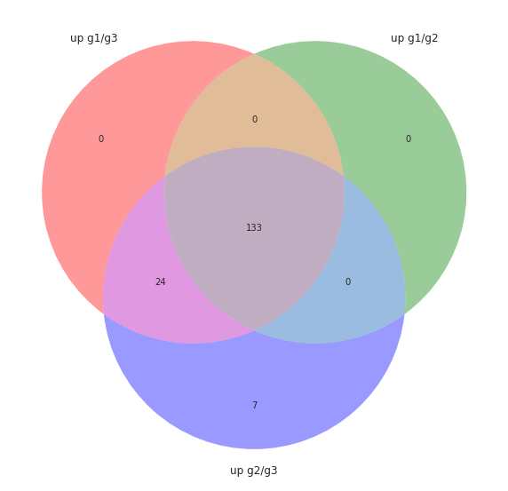

```python
plt.figure(figsize=(10,10))


vd = venn3_unweighted([a, b,c], ('up g1/g3', 'up g1/g2','up g2/g3'))

plt.show()
```

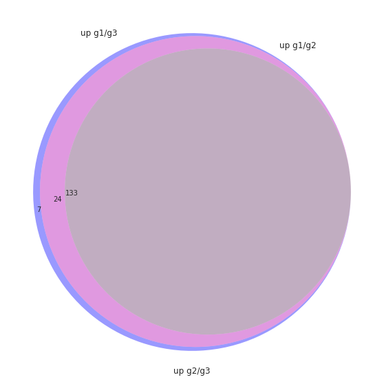

```python
plt.figure(figsize=(10,10))


vd = venn3([a, b,c], ('up g1/g3', 'up g1/g2','up g2/g3'))

plt.show()
```

# Hands-on

- Plot a heatmap for log2(FC) up regulated genes for the 3 comparions (g1/g2, g2/g3 and g1/g3)

# PCA - Principal component analysis

Very nice expanation about PCA: https://stats.stackexchange.com/questions/2691/making-sense-of-principal-component-analysis-eigenvectors-eigenvalues

### Package sklearn - more info at http://scikit-learn.org/stable/index.html

```python
from sklearn import preprocessing
from sklearn.decomposition import PCA
from itertools import cycle
```

```python
heat.head(2)
```

|  | CAM_SMPL_003410 | CAM_SMPL_003375 | CAM_SMPL_003388 | CAM_SMPL_003380 | CAM_SMPL_003361 | CAM_SMPL_003395 | CAM_SMPL_003378 | CAM_SMPL_003365 | CAM_SMPL_003373 | CAM_SMPL_003384 | ... | CAM_SMPL_003369 | CAM_SMPL_003402 | CAM_SMPL_003383 | CAM_SMPL_003377 | CAM_SMPL_003371 | CAM_SMPL_003363 | CAM_SMPL_003389 | CAM_SMPL_003393 | CAM_SMPL_003411 | CAM_SMPL_003416 |
| --- | --- | --- | --- | --- | --- | --- | --- | --- | --- | --- | --- | --- | --- | --- | --- | --- | --- | --- | --- | --- | --- |
| COG0006 - Xaa-Pro aminopeptidase [Amino acid transport and metabolism]. | 1.545723 | 4.167033 | 1.534017 | 0.000000 | 1.724899 | 0.0 | 2.217853 | 6.629477 | 0.0 | 2.193711 | ... | 2.495555 | 1.735013 | 0.0 | 5.705442 | 4.956612 | 3.911169 | 1.068351 | 2.793754 | 5.592646 | 4.276987 |
| COG0018 - Arginyl-tRNA synthetase [Translation, ribosomal structure and biogenesis]. | 1.024882 | 3.036821 | 2.855767 | 4.149942 | 0.000000 | 0.0 | 3.104112 | 3.991667 | 0.0 | 4.225001 | ... | 2.951984 | 3.135016 | 0.0 | 4.945343 | 3.899876 | 3.066643 | 0.000000 | 4.223395 | 4.434279 | 2.736568 |

2 rows × 63 columns

```python
len(heat)
```

```
164
```

```python
# we have 164 COGs, that means, we have 164 variables to be transformed to 2 (or more) dimensions
```

```python
df_pca=heat.T.reset_index()
```

```python
df_pca.head()
```

|  | index | COG0006 - Xaa-Pro aminopeptidase [Amino acid transport and metabolism]. | COG0018 - Arginyl-tRNA synthetase [Translation, ribosomal structure and biogenesis]. | COG0020 - Undecaprenyl pyrophosphate synthase [Lipid transport and metabolism]. | COG0021 - Transketolase [Carbohydrate transport and metabolism]. | COG0028 - Acetolactate synthase large subunit or other thiamine pyrophosphate-requiring enzyme [Amino acid transport and metabolism, Coenzyme transport and metabolism]. | COG0035 - Uracil phosphoribosyltransferase [Nucleotide transport and metabolism]. | COG0040 - ATP phosphoribosyltransferase [Amino acid transport and metabolism]. | COG0049 - Ribosomal protein S7 [Translation, ribosomal structure and biogenesis]. | COG0050 - Translation elongation factor EF-Tu, a GTPase [Translation, ribosomal structure and biogenesis]. | ... | COG4270 - Uncharacterized membrane protein [Function unknown]. | COG4567 - Two-component response regulator, ActR/RegA family, consists of REC and Fis-type HTH domains [Signal transduction mechanisms, Transcription]. | COG4579 - Isocitrate dehydrogenase kinase/phosphatase [Signal transduction mechanisms]. | COG4581 - Superfamily II RNA helicase [Replication, recombination and repair]. | COG4618 - ABC-type protease/lipase transport system, ATPase and permease components [Intracellular trafficking, secretion, and vesicular transport]. | COG4663 - TRAP-type mannitol/chloroaromatic compound transport system, periplasmic component [Secondary metabolites biosynthesis, transport and catabolism]. | COG4666 - TRAP-type uncharacterized transport system, fused permease components [General function prediction only]. | COG4977 - Transcriptional regulator GlxA family, contains an amidase domain and an AraC-type DNA-binding HTH domain [Transcription]. | COG5009 - Membrane carboxypeptidase/penicillin-binding protein [Cell wall/membrane/envelope biogenesis]. | COG5282 - Uncharacterized conserved protein, DUF2342 family [Function unknown]. |
| --- | --- | --- | --- | --- | --- | --- | --- | --- | --- | --- | --- | --- | --- | --- | --- | --- | --- | --- | --- | --- | --- |
| 0 | CAM_SMPL_003410 | 1.545723 | 1.024882 | 0.000000 | 0.659364 | 1.799150 | 0.000000 | 0.637089 | 0.000000 | 6.583426 | ... | 0.0 | 0.000000 | 0.000000 | 0.000000 | 0.000000 | 0.000000 | 1.486878 | 0.000000 | 2.201261 | 0.000000 |
| 1 | CAM_SMPL_003375 | 4.167033 | 3.036821 | 3.220692 | 2.388176 | 6.434617 | 0.745211 | 0.948030 | 0.000000 | 4.057610 | ... | 0.0 | 1.114127 | 0.202873 | 2.062192 | 0.287403 | 4.738382 | 2.831516 | 2.353076 | 4.581341 | 0.000000 |
| 2 | CAM_SMPL_003388 | 1.534017 | 2.855767 | 0.973403 | 1.485892 | 4.867390 | 0.205852 | 1.106626 | 0.875543 | 4.395697 | ... | 0.0 | 0.249309 | 0.600689 | 0.452479 | 0.484652 | 2.253002 | 3.081664 | 0.733418 | 2.113862 | 0.439787 |
| 3 | CAM_SMPL_003380 | 0.000000 | 4.149942 | 0.000000 | 0.000000 | 0.000000 | 0.000000 | 0.000000 | 0.000000 | 2.263685 | ... | 0.0 | 0.000000 | 0.000000 | 0.000000 | 0.000000 | 0.798198 | 0.000000 | 0.000000 | 0.000000 | 0.682459 |
| 4 | CAM_SMPL_003361 | 1.724899 | 0.000000 | 1.542692 | 0.000000 | 3.255559 | 0.000000 | 0.000000 | 0.000000 | 4.002741 | ... | 0.0 | 0.000000 | 0.000000 | 1.445955 | 0.000000 | 1.043153 | 0.000000 | 0.000000 | 1.035755 | 0.000000 |

5 rows × 165 columns

```python
merged.head()
```

|  | Sample | AGS | GE | AGS - GE | AGS (mb) | SAMPLE_ACC | Sample Type | SAMPLE_VOLUME | VOLUME_UNIT | FILTER_MIN | ... | MATERIAL_ID | sample depth - (m) | Ammonium - (umol/kg) | Silicate - (umol/kg) | Total phosphorus | salinity - (psu) | temperature - (C) | nitrite - (µmol/l) | phosphate - (umol/kg) | nitrate(NO3) - (umol/l) |
| --- | --- | --- | --- | --- | --- | --- | --- | --- | --- | --- | --- | --- | --- | --- | --- | --- | --- | --- | --- | --- | --- |
| 0 | CAM_SMPL_003378 | 1.109780e+06 | 41.574616 | 1.109738e+06 | 1.109780 | CAM_SMPL_003378 | metagenome | 180 | L | 0.1 | ... | 3807 | 1 | 0.237 | 7.113 | 0.201 | 4.79 | 15.31 | NaN | 0.042 | 0.215 |
| 1 | CAM_SMPL_003396 | 9.275912e+05 | 32.594154 | 9.275586e+05 | 0.927591 | CAM_SMPL_003396 | metagenome | 200 | L | 0.1 | ... | 3825 | 16 | 0.390 | 9.919 | 0.189 | 4.51 | 10.30 | NaN | 0.030 | 0.344 |
| 2 | CAM_SMPL_003377 | 1.412405e+06 | 19.604380 | 1.412385e+06 | 1.412405 | CAM_SMPL_003377 | metagenome | 200 | L | 0.1 | ... | 3806 | 72 | 0.831 | 16.290 | 1.172 | 34.35 | 6.35 | NaN | 0.913 | 8.538 |
| 3 | CAM_SMPL_003368 | 1.026569e+06 | 12.120798 | 1.026557e+06 | 1.026569 | CAM_SMPL_003368 | metagenome | 200 | L | 0.1 | ... | 3797 | 20 | 0.801 | 5.109 | 0.360 | 31.50 | 15.00 | 0.035 | 0.107 | 1.011 |
| 4 | CAM_SMPL_003371 | 1.456099e+06 | 18.592277 | 1.456081e+06 | 1.456099 | CAM_SMPL_003371 | metagenome | 200 | L | 0.1 | ... | 3800 | 1 | 0.832 | 3.635 | 0.382 | 23.20 | 18.85 | NaN | 0.029 | 0.348 |

5 rows × 36 columns

```python
df_pca=pd.merge(merged[["Sample","FILTER_MIN"]],df_pca,left_on="Sample",right_on="index").drop("index",axis=1)
```

```python
df_pca.set_index(["Sample","FILTER_MIN"],inplace=True)
```

```python
df_pca.head()
```

| Sample | FILTER_MIN | COG0006 - Xaa-Pro aminopeptidase [Amino acid transport and metabolism]. | COG0018 - Arginyl-tRNA synthetase [Translation, ribosomal structure and biogenesis]. | COG0020 - Undecaprenyl pyrophosphate synthase [Lipid transport and metabolism]. | COG0021 - Transketolase [Carbohydrate transport and metabolism]. | COG0028 - Acetolactate synthase large subunit or other thiamine pyrophosphate-requiring enzyme [Amino acid transport and metabolism, Coenzyme transport and metabolism]. | COG0035 - Uracil phosphoribosyltransferase [Nucleotide transport and metabolism]. | COG0040 - ATP phosphoribosyltransferase [Amino acid transport and metabolism]. | COG0049 - Ribosomal protein S7 [Translation, ribosomal structure and biogenesis]. | COG0050 - Translation elongation factor EF-Tu, a GTPase [Translation, ribosomal structure and biogenesis]. | COG0064 - Asp-tRNAAsn/Glu-tRNAGln amidotransferase B subunit [Translation, ribosomal structure and biogenesis]. | ... | COG4270 - Uncharacterized membrane protein [Function unknown]. | COG4567 - Two-component response regulator, ActR/RegA family, consists of REC and Fis-type HTH domains [Signal transduction mechanisms, Transcription]. | COG4579 - Isocitrate dehydrogenase kinase/phosphatase [Signal transduction mechanisms]. | COG4581 - Superfamily II RNA helicase [Replication, recombination and repair]. | COG4618 - ABC-type protease/lipase transport system, ATPase and permease components [Intracellular trafficking, secretion, and vesicular transport]. | COG4663 - TRAP-type mannitol/chloroaromatic compound transport system, periplasmic component [Secondary metabolites biosynthesis, transport and catabolism]. | COG4666 - TRAP-type uncharacterized transport system, fused permease components [General function prediction only]. | COG4977 - Transcriptional regulator GlxA family, contains an amidase domain and an AraC-type DNA-binding HTH domain [Transcription]. | COG5009 - Membrane carboxypeptidase/penicillin-binding protein [Cell wall/membrane/envelope biogenesis]. | COG5282 - Uncharacterized conserved protein, DUF2342 family [Function unknown]. |
| --- | --- | --- | --- | --- | --- | --- | --- | --- | --- | --- | --- | --- | --- | --- | --- | --- | --- | --- | --- | --- | --- | --- |
| CAM_SMPL_003378 | 0.1 | 2.217853 | 3.104112 | 1.481556 | 4.185504 | 4.231023 | 2.261908 | 1.789779 | 1.927435 | 4.193771 | 2.973363 | ... | 0.485059 | 1.100603 | 0.00000 | 1.987316 | 0.053097 | 1.655937 | 2.973762 | 0.167036 | 2.066227 | 1.372959 |
| CAM_SMPL_003396 | 0.1 | 2.196063 | 2.807988 | 2.328216 | 2.349802 | 4.251768 | 1.305508 | 1.702963 | 0.884343 | 4.409935 | 3.170220 | ... | 0.247442 | 0.396387 | 0.00000 | 1.750147 | 0.000000 | 0.447497 | 1.955898 | 0.000000 | 1.745357 | 0.617174 |
| CAM_SMPL_003377 | 0.1 | 5.705442 | 4.945343 | 0.564016 | 3.891734 | 12.182144 | 0.975872 | 1.960872 | 0.555654 | 5.793683 | 5.142208 | ... | 0.000000 | 1.231687 | 0.30636 | 1.153844 | 0.333392 | 4.756444 | 3.005515 | 0.000000 | 4.137977 | 0.000000 |
| CAM_SMPL_003368 | 0.1 | 2.968671 | 1.863295 | 1.602269 | 1.672952 | 6.762408 | 0.000000 | 1.227721 | 0.759965 | 1.260330 | 0.868506 | ... | 0.000000 | 3.062030 | 0.00000 | 0.327392 | 0.000000 | 2.792441 | 2.953601 | 0.000000 | 3.896846 | 0.000000 |
| CAM_SMPL_003371 | 0.1 | 4.956612 | 3.899876 | 2.604266 | 4.769148 | 8.260903 | 1.841765 | 1.767899 | 0.655986 | 7.253030 | 3.634597 | ... | 0.000000 | 2.231739 | 0.00000 | 1.705530 | 0.000000 | 4.657529 | 1.095331 | 0.697874 | 6.642156 | 1.049109 |

5 rows × 164 columns

```python
pca = PCA(copy=True, iterated_power='auto', n_components=2, random_state=None,
  svd_solver='auto', tol=0.0, whiten=False)

#scaling the values
df_pca_scaled = preprocessing.scale(df_pca)

projected=pca.fit_transform(df_pca_scaled)
```

```python
print(pca.explained_variance_ratio_)
```

```
[0.42767701 0.09641663]
```

```python
tmp=pd.DataFrame(projected)
tmp.rename(columns={0: 'Component 1',1: 'Component 2'}, inplace=True)
tmp.head()
```

|  | Component 1 | Component 2 |
| --- | --- | --- |
| 0 | 11.114657 | -5.224373 |
| 1 | 7.793254 | -6.231991 |
| 2 | 10.776208 | 1.192819 |
| 3 | 0.830403 | -2.127450 |
| 4 | 11.567918 | 1.184126 |

```python
final_pca=pd.merge(df_pca.reset_index(),tmp,left_index=True,right_index=True)
```

```python
# in the final_pca dataframe, in adition to all the COGs,
# we have new columns (0 and 1), with the PCA results (2 components)
```

```python
final_pca.head()
```

|  | Sample | FILTER_MIN | COG0006 - Xaa-Pro aminopeptidase [Amino acid transport and metabolism]. | COG0018 - Arginyl-tRNA synthetase [Translation, ribosomal structure and biogenesis]. | COG0020 - Undecaprenyl pyrophosphate synthase [Lipid transport and metabolism]. | COG0021 - Transketolase [Carbohydrate transport and metabolism]. | COG0028 - Acetolactate synthase large subunit or other thiamine pyrophosphate-requiring enzyme [Amino acid transport and metabolism, Coenzyme transport and metabolism]. | COG0035 - Uracil phosphoribosyltransferase [Nucleotide transport and metabolism]. | COG0040 - ATP phosphoribosyltransferase [Amino acid transport and metabolism]. | COG0049 - Ribosomal protein S7 [Translation, ribosomal structure and biogenesis]. | ... | COG4579 - Isocitrate dehydrogenase kinase/phosphatase [Signal transduction mechanisms]. | COG4581 - Superfamily II RNA helicase [Replication, recombination and repair]. | COG4618 - ABC-type protease/lipase transport system, ATPase and permease components [Intracellular trafficking, secretion, and vesicular transport]. | COG4663 - TRAP-type mannitol/chloroaromatic compound transport system, periplasmic component [Secondary metabolites biosynthesis, transport and catabolism]. | COG4666 - TRAP-type uncharacterized transport system, fused permease components [General function prediction only]. | COG4977 - Transcriptional regulator GlxA family, contains an amidase domain and an AraC-type DNA-binding HTH domain [Transcription]. | COG5009 - Membrane carboxypeptidase/penicillin-binding protein [Cell wall/membrane/envelope biogenesis]. | COG5282 - Uncharacterized conserved protein, DUF2342 family [Function unknown]. | Component 1 | Component 2 |
| --- | --- | --- | --- | --- | --- | --- | --- | --- | --- | --- | --- | --- | --- | --- | --- | --- | --- | --- | --- | --- | --- |
| 0 | CAM_SMPL_003378 | 0.1 | 2.217853 | 3.104112 | 1.481556 | 4.185504 | 4.231023 | 2.261908 | 1.789779 | 1.927435 | ... | 0.00000 | 1.987316 | 0.053097 | 1.655937 | 2.973762 | 0.167036 | 2.066227 | 1.372959 | 11.114657 | -5.224373 |
| 1 | CAM_SMPL_003396 | 0.1 | 2.196063 | 2.807988 | 2.328216 | 2.349802 | 4.251768 | 1.305508 | 1.702963 | 0.884343 | ... | 0.00000 | 1.750147 | 0.000000 | 0.447497 | 1.955898 | 0.000000 | 1.745357 | 0.617174 | 7.793254 | -6.231991 |
| 2 | CAM_SMPL_003377 | 0.1 | 5.705442 | 4.945343 | 0.564016 | 3.891734 | 12.182144 | 0.975872 | 1.960872 | 0.555654 | ... | 0.30636 | 1.153844 | 0.333392 | 4.756444 | 3.005515 | 0.000000 | 4.137977 | 0.000000 | 10.776208 | 1.192819 |
| 3 | CAM_SMPL_003368 | 0.1 | 2.968671 | 1.863295 | 1.602269 | 1.672952 | 6.762408 | 0.000000 | 1.227721 | 0.759965 | ... | 0.00000 | 0.327392 | 0.000000 | 2.792441 | 2.953601 | 0.000000 | 3.896846 | 0.000000 | 0.830403 | -2.127450 |
| 4 | CAM_SMPL_003371 | 0.1 | 4.956612 | 3.899876 | 2.604266 | 4.769148 | 8.260903 | 1.841765 | 1.767899 | 0.655986 | ... | 0.00000 | 1.705530 | 0.000000 | 4.657529 | 1.095331 | 0.697874 | 6.642156 | 1.049109 | 11.567918 | 1.184126 |

5 rows × 168 columns

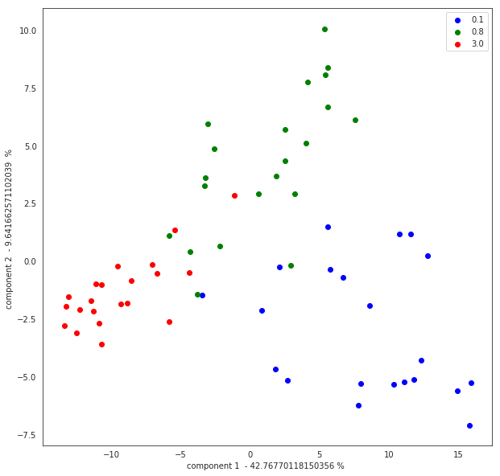

```python
sns.set_style("white")
color_gen = cycle(('blue', 'green', 'red'))
plt.figure(figsize=(10,10))
for lab in set(final_pca["FILTER_MIN"]):
    plt.scatter(final_pca.loc[final_pca['FILTER_MIN'] == lab, 'Component 1'],
                final_pca.loc[final_pca['FILTER_MIN'] == lab, 'Component 2'],
                c=next(color_gen),
                label=lab)



plt.xlabel('component 1  - ' + str(pca.explained_variance_ratio_[0]*100)+ " % " )
plt.ylabel('component 2  - '+ str(pca.explained_variance_ratio_[1]*100)+ "  % " )
plt.legend(loc='best')
plt.show()
```

```python
#pca.components_
```

```python
components = pd.DataFrame(pca.components_, columns = df_pca.columns, index=[1, 2])
```

```python
# Principal axes in feature space, representing the directions of maximum variance in the data.
components
```

|  | COG0006 - Xaa-Pro aminopeptidase [Amino acid transport and metabolism]. | COG0018 - Arginyl-tRNA synthetase [Translation, ribosomal structure and biogenesis]. | COG0020 - Undecaprenyl pyrophosphate synthase [Lipid transport and metabolism]. | COG0021 - Transketolase [Carbohydrate transport and metabolism]. | COG0028 - Acetolactate synthase large subunit or other thiamine pyrophosphate-requiring enzyme [Amino acid transport and metabolism, Coenzyme transport and metabolism]. | COG0035 - Uracil phosphoribosyltransferase [Nucleotide transport and metabolism]. | COG0040 - ATP phosphoribosyltransferase [Amino acid transport and metabolism]. | COG0049 - Ribosomal protein S7 [Translation, ribosomal structure and biogenesis]. | COG0050 - Translation elongation factor EF-Tu, a GTPase [Translation, ribosomal structure and biogenesis]. | COG0064 - Asp-tRNAAsn/Glu-tRNAGln amidotransferase B subunit [Translation, ribosomal structure and biogenesis]. | ... | COG4270 - Uncharacterized membrane protein [Function unknown]. | COG4567 - Two-component response regulator, ActR/RegA family, consists of REC and Fis-type HTH domains [Signal transduction mechanisms, Transcription]. | COG4579 - Isocitrate dehydrogenase kinase/phosphatase [Signal transduction mechanisms]. | COG4581 - Superfamily II RNA helicase [Replication, recombination and repair]. | COG4618 - ABC-type protease/lipase transport system, ATPase and permease components [Intracellular trafficking, secretion, and vesicular transport]. | COG4663 - TRAP-type mannitol/chloroaromatic compound transport system, periplasmic component [Secondary metabolites biosynthesis, transport and catabolism]. | COG4666 - TRAP-type uncharacterized transport system, fused permease components [General function prediction only]. | COG4977 - Transcriptional regulator GlxA family, contains an amidase domain and an AraC-type DNA-binding HTH domain [Transcription]. | COG5009 - Membrane carboxypeptidase/penicillin-binding protein [Cell wall/membrane/envelope biogenesis]. | COG5282 - Uncharacterized conserved protein, DUF2342 family [Function unknown]. |
| --- | --- | --- | --- | --- | --- | --- | --- | --- | --- | --- | --- | --- | --- | --- | --- | --- | --- | --- | --- | --- | --- |
| 1 | 0.082970 | 0.084591 | 0.082658 | 0.098450 | 0.086372 | 0.068815 | 0.097695 | 0.066942 | 0.074851 | 0.078895 | ... | 0.051625 | 0.064301 | 0.019433 | 0.079009 | 0.011210 | 0.072247 | 0.068873 | 0.015234 | 0.087356 | 0.078763 |
| 2 | 0.046882 | 0.012706 | -0.004711 | 0.001974 | 0.060956 | -0.074238 | -0.023298 | -0.070354 | 0.075204 | -0.023305 | ... | -0.072290 | -0.043273 | 0.173289 | -0.058145 | 0.157041 | 0.055173 | 0.084453 | 0.170450 | 0.060258 | -0.099727 |

2 rows × 164 columns

```python
import math

def get_important_features(transformed_features, components_, columns):
    """
    This function will return the most "important"
    features so we can determine which have the most
    effect on multi-dimensional scaling
    """
    num_columns = len(columns)

    # Scale the principal components by the max value in
    # the transformed set belonging to that component
    xvector = components_[0] * max(transformed_features[:,0])
    yvector = components_[1] * max(transformed_features[:,1])

    # Sort each column by it's length. These are your *original*
    # columns, not the principal components.
    important_features = { columns[i] : math.sqrt(xvector[i]**2 + yvector[i]**2) for i in range(num_columns) }
    important_features = sorted(zip(important_features.values(), important_features.keys()), reverse=True)
    return important_features,xvector,yvector
```

```python
important_features,xvector,yvector=get_important_features(projected, pca.components_, df_pca.columns.values)
```

```python
def draw_vectors(transformed_features, components_, columns):
    """
    This funtion will project your *original* features
    onto your principal component feature-space, so that you can
    visualize how "important" each one was in the
    multi-dimensional scaling
    """

    num_columns = len(columns)

    # Scale the principal components by the max value in
    # the transformed set belonging to that component
    xvector = components_[0] * max(transformed_features[:,0])
    yvector = components_[1] * max(transformed_features[:,1])

    # Sort each column by it's length. These are your *original*
    # columns, not the principal components.
    important_features = { columns[i] : math.sqrt(xvector[i]**2 + yvector[i]**2) for i in range(num_columns) }
    important_features = sorted(zip(important_features.values(), important_features.keys()), reverse=True)

    ax = plt.axes()

    tmp=pd.DataFrame({"xvector":xvector,"columns":columns} )
    tmp2=pd.DataFrame({"yvector":yvector,"columns":columns} )


    azip=zip(xvector,columns)
    azip2=zip(yvector,columns)
    col_array=[]

    # Use an arrow to project each original feature as a
    # labeled vector on your principal component axes
    for i in range(num_columns):

        if columns[i]==tmp[tmp["xvector"]==max(xvector)]["columns"].tolist()[0]:
            plt.arrow(0, 0, xvector[i], yvector[i], color='b', width=0.0005, head_width=0.02, alpha=0.75)
            plt.text(xvector[i]*1.2, yvector[i]*1.2, list(columns)[i], color='b', alpha=0.75)
            col_array.append(columns[i])
        if columns[i]==tmp[tmp["xvector"]==min(xvector)]["columns"].tolist()[0]:
            plt.arrow(0, 0, xvector[i], yvector[i], color='b', width=0.0005, head_width=0.02, alpha=0.75)
            plt.text(xvector[i]*1.2, yvector[i]*1.2, list(columns)[i], color='b', alpha=0.75)
            col_array.append(columns[i])
        if columns[i]==tmp2[tmp2["yvector"]==min(yvector)]["columns"].tolist()[0]:
            plt.arrow(0, 0, xvector[i], yvector[i], color='b', width=0.0005, head_width=0.02, alpha=0.75)
            plt.text(xvector[i]*1.2, yvector[i]*1.2, list(columns)[i], color='b', alpha=0.75)
            col_array.append(columns[i])
        if columns[i]==tmp2[tmp2["yvector"]==min(yvector)]["columns"].tolist()[0]:
            plt.arrow(0, 0, xvector[i], yvector[i], color='b', width=0.0005, head_width=0.02, alpha=0.75)
            plt.text(xvector[i]*1.2, yvector[i]*1.2, list(columns)[i], color='b', alpha=0.75)
            col_array.append(columns[i])

    return ax,col_array
```

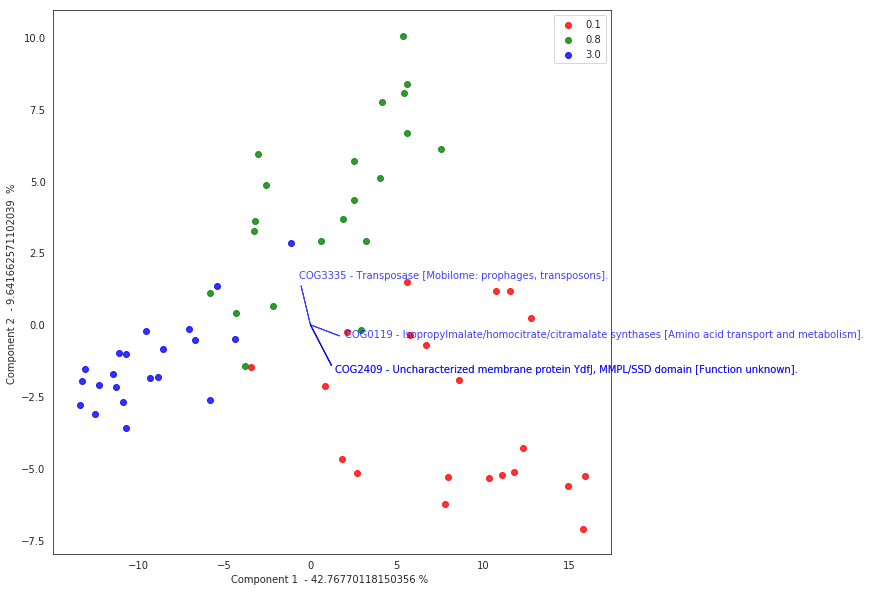

```python
color_gen = cycle(('red', 'green', 'blue'))
plt.figure(figsize=(10,10))
for lab in set(final_pca["FILTER_MIN"]):
    plt.scatter(final_pca.loc[final_pca['FILTER_MIN'] == lab, 'Component 1'],
                final_pca.loc[final_pca['FILTER_MIN'] == lab, 'Component 2'],
                c=next(color_gen),
                label=lab,alpha=0.8)

ax,cols=draw_vectors(projected, pca.components_, df_pca.columns.values)

plt.xlabel('Component 1  - ' + str(pca.explained_variance_ratio_[0]*100)+ " % " )
plt.ylabel('Component 2  - '+ str(pca.explained_variance_ratio_[1]*100)+ "  % " )
plt.legend(loc='best')
plt.show()
```

# Hands-on:

- Plot the same PCA, but fixing the text on arrows (keeping only COG number, removing the descriptions)
- Add a vertical line and a horizontal line on zero values

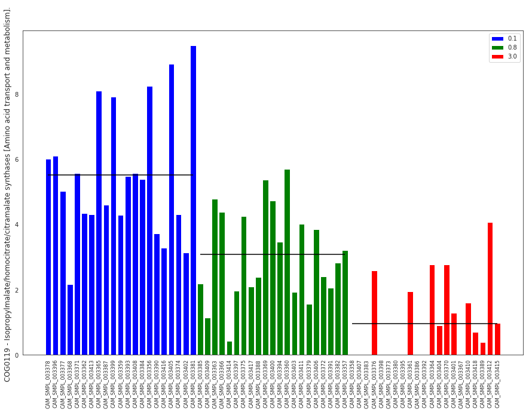

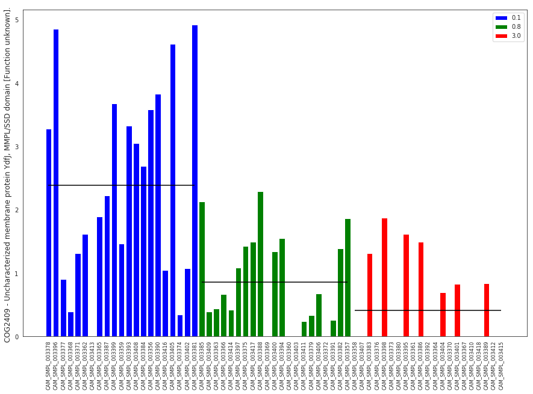

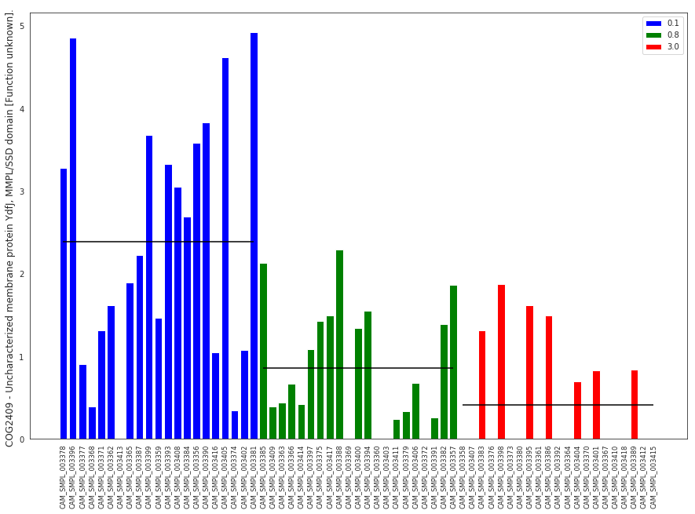

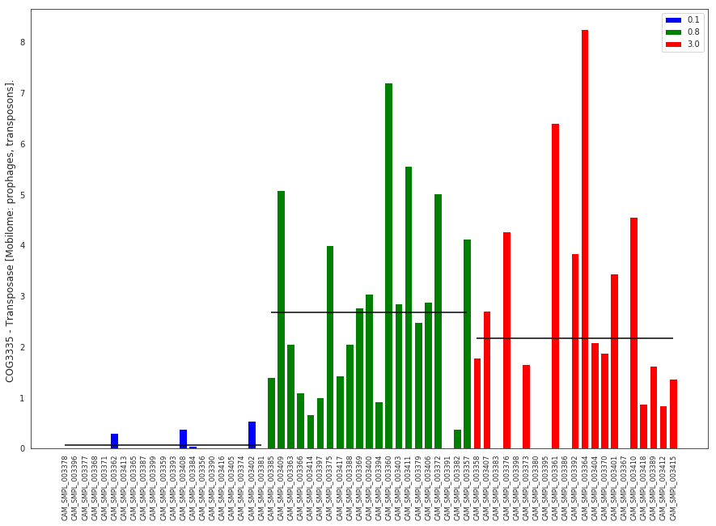

```python
sns.set_style("white")
plt.figure(figsize=(15,10))
tmp=final_pca[final_pca['Sample'].isin(g1_["Sample"])]
tmp2=final_pca[final_pca['Sample'].isin(g2_["Sample"])]
tmp3=final_pca[final_pca['Sample'].isin(g3_["Sample"])]
for c in cols:
    plt.figure(figsize=(15,10))
    plt.bar(tmp.index,tmp[c],color="b")
    plt.bar(tmp2.index,tmp2[c],color="g")
    plt.bar(tmp3.index,tmp3[c],color="r")
    plt.ylabel(c,size="12")
    plt.xticks(range(len(final_pca)), final_pca["Sample"], size='small',rotation="vertical")
    plt.legend(final_pca["FILTER_MIN"].drop_duplicates())

    #here we plot 3 horizontal lines (hlines) with the mean of AGS values for each group
    plt.hlines(tmp[c].astype(float).mean(),g1_.index[0],g1_.index[-1])
    plt.hlines(tmp2[c].astype(float).mean(),g2_.index[0],g2_.index[-1])
    plt.hlines(tmp3[c].astype(float).mean(),g3_.index[0],g3_.index[-1])
    plt.show()
```

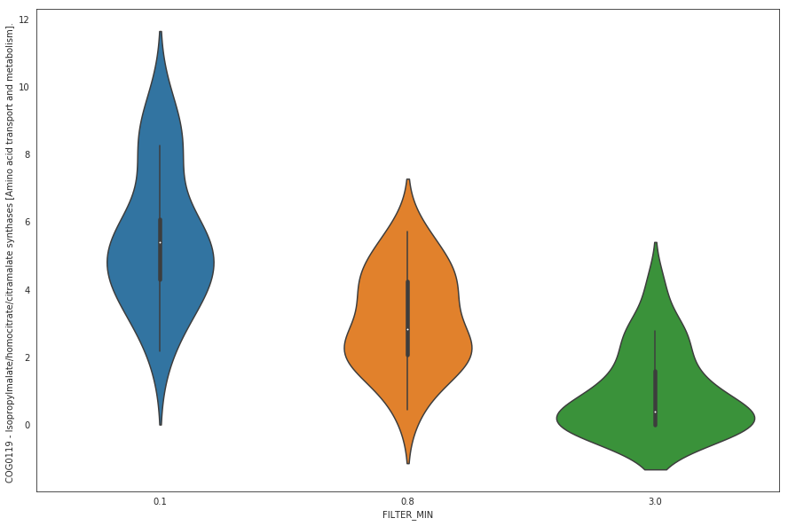

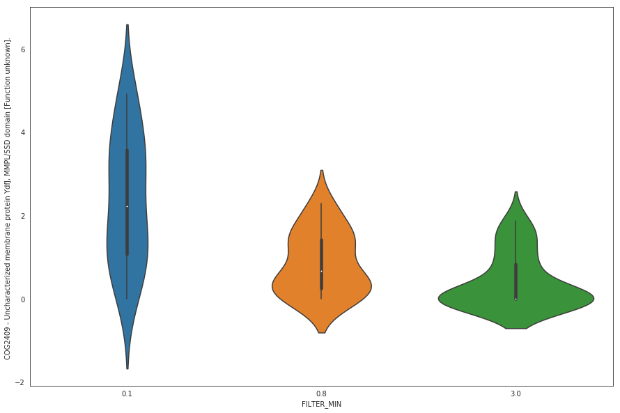

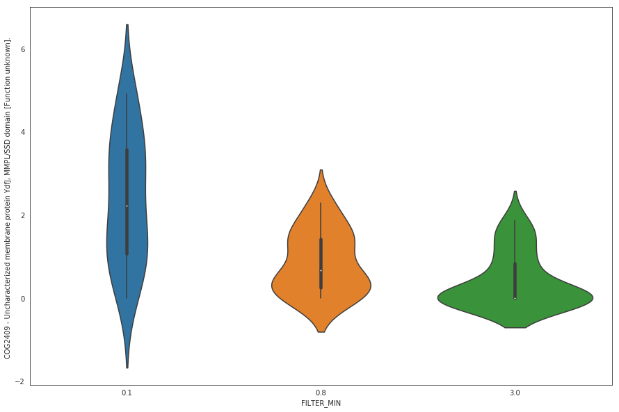

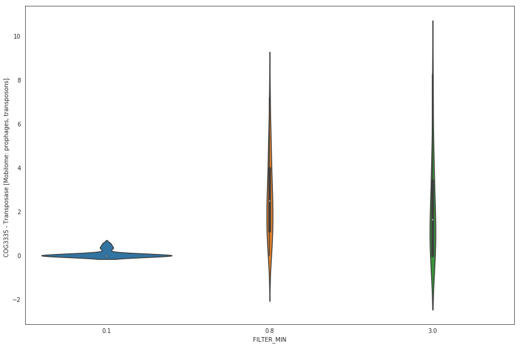

```python
sns.set_style("white")

for c in cols:
    plt.figure(figsize=(15,10))
    x=final_pca["FILTER_MIN"]
    y=final_pca[c]
    sns.violinplot(x,y)
plt.show()
```

```python
## Kmeans

## clusterization (kmeans with euc distance)
## calculate distance btw centroid of clusters and each gene
## plot bar plots for the genes with shorter and bigger distance from one cluster

### a bit more about K-means: https://datasciencelab.wordpress.com/2013/12/12/clustering-with-k-means-in-python/
```

[output not shown]

```python
def dist(a, b, ax=1):
    return np.linalg.norm(a - b, axis=ax)
```

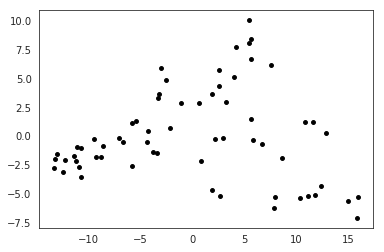

```python
f1 = final_pca["Component 1"].values
f2 = final_pca["Component 2"].values
X = np.array(list(zip(f1, f2)))
plt.scatter(f1, f2, c='black', s=15)
plt.show()
```

```python
from sklearn.cluster import KMeans
from scipy.spatial.distance import cdist
```

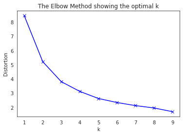

```python
# k means determine k
distortions = []
K = range(1,10)
for k in K:
    kmeanModel = KMeans(n_clusters=k).fit(X)
    kmeanModel.fit(X)
    distortions.append(sum(np.min(cdist(X, kmeanModel.cluster_centers_, 'euclidean'), axis=1)) / X.shape[0])

# Plot the elbow
plt.plot(K, distortions, 'bx-')
plt.xlabel('k')
plt.ylabel('Distortion')
plt.title('The Elbow Method showing the optimal k')
plt.show()
```

```python
from sklearn.cluster import KMeans

# Number of clusters
k=3
kmeans = KMeans(n_clusters=k)
# Fitting the input data
kmeans = kmeans.fit(X)
# Getting the cluster labels
labels = kmeans.predict(X)
# Centroid values
C = kmeans.cluster_centers_
```

```python
print(C)
```

```
[[-8.89103651 -1.33884732]
 [ 9.92669966 -3.51000995]
 [ 2.028681    4.17284112]]
```

```python
from copy import deepcopy
```

```python
# colors = ['#FF0000', 'g', '#FF7D40', '#66CDAA', '#473C8B', '#9400D3','#8B8386','#FFC0CB','#B0171F']
# fig, ax = plt.subplots()
# for i in range(k):
#         points = np.array([X[j] for j in range(len(X)) if clusters[j] == i])
#         ax.scatter(points[:, 0], points[:, 1], s=15, c=colors[i])
# ax.scatter(C[:, 0], C[:, 1], marker='*', s=100, c='#050505')
# plt.show()
```

```python
kmeans.labels_
```

```
array([1, 1, 1, 2, 1, 1, 0, 1, 1, 1, 1, 1, 1, 1, 1, 1, 2, 1, 1, 2, 1, 0,
       2, 2, 2, 2, 2, 2, 2, 2, 2, 2, 2, 2, 2, 2, 2, 2, 2, 0, 0, 2, 0, 0,
       0, 2, 0, 0, 0, 0, 0, 0, 0, 0, 0, 0, 0, 0, 0, 0, 0, 0, 0],
      dtype=int32)
```

```python
final_pca.head()
```

|  | Sample | FILTER_MIN | COG0006 - Xaa-Pro aminopeptidase [Amino acid transport and metabolism]. | COG0018 - Arginyl-tRNA synthetase [Translation, ribosomal structure and biogenesis]. | COG0020 - Undecaprenyl pyrophosphate synthase [Lipid transport and metabolism]. | COG0021 - Transketolase [Carbohydrate transport and metabolism]. | COG0028 - Acetolactate synthase large subunit or other thiamine pyrophosphate-requiring enzyme [Amino acid transport and metabolism, Coenzyme transport and metabolism]. | COG0035 - Uracil phosphoribosyltransferase [Nucleotide transport and metabolism]. | COG0040 - ATP phosphoribosyltransferase [Amino acid transport and metabolism]. | COG0049 - Ribosomal protein S7 [Translation, ribosomal structure and biogenesis]. | ... | COG4579 - Isocitrate dehydrogenase kinase/phosphatase [Signal transduction mechanisms]. | COG4581 - Superfamily II RNA helicase [Replication, recombination and repair]. | COG4618 - ABC-type protease/lipase transport system, ATPase and permease components [Intracellular trafficking, secretion, and vesicular transport]. | COG4663 - TRAP-type mannitol/chloroaromatic compound transport system, periplasmic component [Secondary metabolites biosynthesis, transport and catabolism]. | COG4666 - TRAP-type uncharacterized transport system, fused permease components [General function prediction only]. | COG4977 - Transcriptional regulator GlxA family, contains an amidase domain and an AraC-type DNA-binding HTH domain [Transcription]. | COG5009 - Membrane carboxypeptidase/penicillin-binding protein [Cell wall/membrane/envelope biogenesis]. | COG5282 - Uncharacterized conserved protein, DUF2342 family [Function unknown]. | Component 1 | Component 2 |
| --- | --- | --- | --- | --- | --- | --- | --- | --- | --- | --- | --- | --- | --- | --- | --- | --- | --- | --- | --- | --- | --- |
| 0 | CAM_SMPL_003378 | 0.1 | 2.217853 | 3.104112 | 1.481556 | 4.185504 | 4.231023 | 2.261908 | 1.789779 | 1.927435 | ... | 0.00000 | 1.987316 | 0.053097 | 1.655937 | 2.973762 | 0.167036 | 2.066227 | 1.372959 | 11.114657 | -5.224373 |
| 1 | CAM_SMPL_003396 | 0.1 | 2.196063 | 2.807988 | 2.328216 | 2.349802 | 4.251768 | 1.305508 | 1.702963 | 0.884343 | ... | 0.00000 | 1.750147 | 0.000000 | 0.447497 | 1.955898 | 0.000000 | 1.745357 | 0.617174 | 7.793254 | -6.231991 |
| 2 | CAM_SMPL_003377 | 0.1 | 5.705442 | 4.945343 | 0.564016 | 3.891734 | 12.182144 | 0.975872 | 1.960872 | 0.555654 | ... | 0.30636 | 1.153844 | 0.333392 | 4.756444 | 3.005515 | 0.000000 | 4.137977 | 0.000000 | 10.776208 | 1.192819 |
| 3 | CAM_SMPL_003368 | 0.1 | 2.968671 | 1.863295 | 1.602269 | 1.672952 | 6.762408 | 0.000000 | 1.227721 | 0.759965 | ... | 0.00000 | 0.327392 | 0.000000 | 2.792441 | 2.953601 | 0.000000 | 3.896846 | 0.000000 | 0.830403 | -2.127450 |
| 4 | CAM_SMPL_003371 | 0.1 | 4.956612 | 3.899876 | 2.604266 | 4.769148 | 8.260903 | 1.841765 | 1.767899 | 0.655986 | ... | 0.00000 | 1.705530 | 0.000000 | 4.657529 | 1.095331 | 0.697874 | 6.642156 | 1.049109 | 11.567918 | 1.184126 |

5 rows × 168 columns

```python
from sklearn.metrics import pairwise_distances_argmin_min
```

```python
closest, _ = pairwise_distances_argmin_min(kmeans.cluster_centers_, X)
```

```python
closest
```

```
array([60, 13, 34])
```

```python
final_pca.loc[[34]]
```

|  | Sample | FILTER_MIN | COG0006 - Xaa-Pro aminopeptidase [Amino acid transport and metabolism]. | COG0018 - Arginyl-tRNA synthetase [Translation, ribosomal structure and biogenesis]. | COG0020 - Undecaprenyl pyrophosphate synthase [Lipid transport and metabolism]. | COG0021 - Transketolase [Carbohydrate transport and metabolism]. | COG0028 - Acetolactate synthase large subunit or other thiamine pyrophosphate-requiring enzyme [Amino acid transport and metabolism, Coenzyme transport and metabolism]. | COG0035 - Uracil phosphoribosyltransferase [Nucleotide transport and metabolism]. | COG0040 - ATP phosphoribosyltransferase [Amino acid transport and metabolism]. | COG0049 - Ribosomal protein S7 [Translation, ribosomal structure and biogenesis]. | ... | COG4579 - Isocitrate dehydrogenase kinase/phosphatase [Signal transduction mechanisms]. | COG4581 - Superfamily II RNA helicase [Replication, recombination and repair]. | COG4618 - ABC-type protease/lipase transport system, ATPase and permease components [Intracellular trafficking, secretion, and vesicular transport]. | COG4663 - TRAP-type mannitol/chloroaromatic compound transport system, periplasmic component [Secondary metabolites biosynthesis, transport and catabolism]. | COG4666 - TRAP-type uncharacterized transport system, fused permease components [General function prediction only]. | COG4977 - Transcriptional regulator GlxA family, contains an amidase domain and an AraC-type DNA-binding HTH domain [Transcription]. | COG5009 - Membrane carboxypeptidase/penicillin-binding protein [Cell wall/membrane/envelope biogenesis]. | COG5282 - Uncharacterized conserved protein, DUF2342 family [Function unknown]. | Component 1 | Component 2 |
| --- | --- | --- | --- | --- | --- | --- | --- | --- | --- | --- | --- | --- | --- | --- | --- | --- | --- | --- | --- | --- | --- |
| 34 | CAM_SMPL_003403 | 0.8 | 2.388587 | 3.668152 | 1.613449 | 2.843723 | 5.780277 | 0.797623 | 1.491319 | 0.656284 | ... | 0.863644 | 0.0 | 1.079436 | 1.825532 | 0.877082 | 0.572272 | 1.765964 | 0.185048 | 1.883236 | 3.674445 |

1 rows × 168 columns

```python
final_pca.loc[[13]]
```

|  | Sample | FILTER_MIN | COG0006 - Xaa-Pro aminopeptidase [Amino acid transport and metabolism]. | COG0018 - Arginyl-tRNA synthetase [Translation, ribosomal structure and biogenesis]. | COG0020 - Undecaprenyl pyrophosphate synthase [Lipid transport and metabolism]. | COG0021 - Transketolase [Carbohydrate transport and metabolism]. | COG0028 - Acetolactate synthase large subunit or other thiamine pyrophosphate-requiring enzyme [Amino acid transport and metabolism, Coenzyme transport and metabolism]. | COG0035 - Uracil phosphoribosyltransferase [Nucleotide transport and metabolism]. | COG0040 - ATP phosphoribosyltransferase [Amino acid transport and metabolism]. | COG0049 - Ribosomal protein S7 [Translation, ribosomal structure and biogenesis]. | ... | COG4579 - Isocitrate dehydrogenase kinase/phosphatase [Signal transduction mechanisms]. | COG4581 - Superfamily II RNA helicase [Replication, recombination and repair]. | COG4618 - ABC-type protease/lipase transport system, ATPase and permease components [Intracellular trafficking, secretion, and vesicular transport]. | COG4663 - TRAP-type mannitol/chloroaromatic compound transport system, periplasmic component [Secondary metabolites biosynthesis, transport and catabolism]. | COG4666 - TRAP-type uncharacterized transport system, fused permease components [General function prediction only]. | COG4977 - Transcriptional regulator GlxA family, contains an amidase domain and an AraC-type DNA-binding HTH domain [Transcription]. | COG5009 - Membrane carboxypeptidase/penicillin-binding protein [Cell wall/membrane/envelope biogenesis]. | COG5282 - Uncharacterized conserved protein, DUF2342 family [Function unknown]. | Component 1 | Component 2 |
| --- | --- | --- | --- | --- | --- | --- | --- | --- | --- | --- | --- | --- | --- | --- | --- | --- | --- | --- | --- | --- | --- |
| 13 | CAM_SMPL_003384 | 0.1 | 2.193711 | 4.225001 | 3.121637 | 2.988938 | 5.372445 | 0.793944 | 1.35856 | 1.466793 | ... | 0.09558 | 3.063213 | 0.0 | 1.374784 | 2.009722 | 0.178233 | 2.772713 | 0.850626 | 10.354176 | -5.340018 |

1 rows × 168 columns

```python
final_pca.loc[[60]]
```

|  | Sample | FILTER_MIN | COG0006 - Xaa-Pro aminopeptidase [Amino acid transport and metabolism]. | COG0018 - Arginyl-tRNA synthetase [Translation, ribosomal structure and biogenesis]. | COG0020 - Undecaprenyl pyrophosphate synthase [Lipid transport and metabolism]. | COG0021 - Transketolase [Carbohydrate transport and metabolism]. | COG0028 - Acetolactate synthase large subunit or other thiamine pyrophosphate-requiring enzyme [Amino acid transport and metabolism, Coenzyme transport and metabolism]. | COG0035 - Uracil phosphoribosyltransferase [Nucleotide transport and metabolism]. | COG0040 - ATP phosphoribosyltransferase [Amino acid transport and metabolism]. | COG0049 - Ribosomal protein S7 [Translation, ribosomal structure and biogenesis]. | ... | COG4579 - Isocitrate dehydrogenase kinase/phosphatase [Signal transduction mechanisms]. | COG4581 - Superfamily II RNA helicase [Replication, recombination and repair]. | COG4618 - ABC-type protease/lipase transport system, ATPase and permease components [Intracellular trafficking, secretion, and vesicular transport]. | COG4663 - TRAP-type mannitol/chloroaromatic compound transport system, periplasmic component [Secondary metabolites biosynthesis, transport and catabolism]. | COG4666 - TRAP-type uncharacterized transport system, fused permease components [General function prediction only]. | COG4977 - Transcriptional regulator GlxA family, contains an amidase domain and an AraC-type DNA-binding HTH domain [Transcription]. | COG5009 - Membrane carboxypeptidase/penicillin-binding protein [Cell wall/membrane/envelope biogenesis]. | COG5282 - Uncharacterized conserved protein, DUF2342 family [Function unknown]. | Component 1 | Component 2 |
| --- | --- | --- | --- | --- | --- | --- | --- | --- | --- | --- | --- | --- | --- | --- | --- | --- | --- | --- | --- | --- | --- |
| 60 | CAM_SMPL_003389 | 3.0 | 1.068351 | 0.0 | 0.0 | 0.420866 | 1.759561 | 0.706198 | 0.0 | 0.0 | ... | 0.0 | 0.0 | 0.64598 | 1.496105 | 1.522249 | 0.0 | 2.237561 | 0.0 | -8.821492 | -1.807208 |

1 rows × 168 columns